# Report 10.5

Francesco Lucano

# Part 1: Linear regression model and K-Nearest Neighbors (KNN) model

## 1. Setup

```r
library(readr)
library(dplyr)
library(lubridate)
library(ggplot2)
library(rsample)
library(recipes)
library(caret)
library(here)
library(yardstick)
library(tidyr)

# Read the CSV file
flux_data <- readr::read_delim(
  here("data", "FLX_CH-Dav_FLUXNET2015_FULLSET_DD_1997-2014_1-3.csv"),
  delim = ","
)
```

```r
# We clean the data
flux_data_cleaned <- flux_data %>%
  # We elect only the columns we need
  select(
    TIMESTAMP,                 # Keep the timestamp
    GPP_NT_VUT_REF,            # Gross primary production
    NEE_VUT_REF_QC,            # Quality control
    TA_F,                      # Air temperature
    SW_IN_F,                   # Shortwave incoming radiation
    LW_IN_F,                   # Longwave incoming radiation
    VPD_F,                     # Vapor pressure deficit
    P_F,                       # Precipitation
    WS_F                       # Wind speed
  ) %>%
  # We rename GPP column for simplicity
  rename(GPP = GPP_NT_VUT_REF) %>%
  # We convert TIMESTAMP to date object after making it a character
  mutate(TIMESTAMP = as.Date(as.character(TIMESTAMP), format = "%Y%m%d")) %>%
  # We replace -9999 values with NA
   mutate(across(where(is.numeric), ~na_if(.x, -9999))) %>%
  # We filter rows only to keep good quality data (value 1)
  filter(NEE_VUT_REF_QC == 1) %>%
  # We remove rows where any of the remaining columns have NA values
  select(TIMESTAMP, GPP, TA_F, SW_IN_F, LW_IN_F, VPD_F, P_F, WS_F) %>%
  filter(complete.cases(.))
```

## 2. Data splitting (training and testing data)

```r
# We set the seed randomly
set.seed(60249)

# This create the initial split object (70% training, 30% testing).
split_obj <- initial_split(flux_data_cleaned, prop = 0.70, strata = VPD_F)  # We stratify by vapour pressure deficit to ensure that the distribution is similar in both the training set and the testing set

# Extract the training data
train_data <- training(split_obj)

# Extract the testing data
test_data <- testing(split_obj)

# We check the dimensions (number of rows and columns)
dim(flux_data_cleaned)
```

```
## [1] 3739    8
```

```r
dim(train_data)
```

```
## [1] 2616    8
```

```r
dim(test_data)
```

```
## [1] 1123    8
```

```r
# Summary
summary(train_data$VPD_F)
```

```
##    Min. 1st Qu.  Median    Mean 3rd Qu.    Max.
##  0.0010  0.9605  2.2450  2.8299  4.0377 15.5220
```

```r
summary(test_data$VPD_F)
```

```
##    Min. 1st Qu.  Median    Mean 3rd Qu.    Max.
##   0.017   0.962   2.245   2.853   4.048  14.824
```

## 3. Preprocessing

```r
# We define the recipe and we select the numeric predictors
gpp_recipe <- recipe(GPP ~ TA_F + SW_IN_F + LW_IN_F + VPD_F + P_F + WS_F, data = train_data) %>%
  # We apply Yeo-Johnson transformation to all numeric predictors (makes the distributions of the variables more normal-like). We use it over the Box-Cox because because Box-Cox requires strictly positive (> 0) values, and our data includes non-positive values in TA_F (negative) and P_F (zero)
  step_YeoJohnson(all_predictors()) %>%
  # We center all numeric predictors (subtract mean)
  step_center(all_predictors()) %>%
  # We scale all numeric predictors (divide by standard deviation)
  step_scale(all_predictors())

# Print the recipe
print(gpp_recipe)
```

## 4. Linear regression (LM) model

```r
# We set the seed and set up training control for 10-fold cross-validation
set.seed(60249)
train_control <- trainControl(method = "cv", number = 10)

# We train the linear model using the recipe found in step 3, the training data and we specify that we want a linear regression method and cross-validation
lm_fit <- train(
  x = gpp_recipe,
  data = train_data,
  method = "lm",
  trControl = train_control
)

# Print the results summary
print(lm_fit)
```

```
## Linear Regression
##
## 2616 samples
##    7 predictor
##
## Recipe steps: YeoJohnson, center, scale
## Resampling: Cross-Validated (10 fold)
## Summary of sample sizes: 2353, 2354, 2355, 2354, 2355, 2355, ...
## Resampling results:
##
##   RMSE      Rsquared   MAE
##   1.514848  0.6980356  1.178321
##
## Tuning parameter 'intercept' was held constant at a value of TRUE
```

### 4.1. Liner regression model evaluation on test data

```
## Linear Model (lm) Performance on test set:
## RMSE: 1.537
## R-squared: 0.688
## MAE: 1.185
```

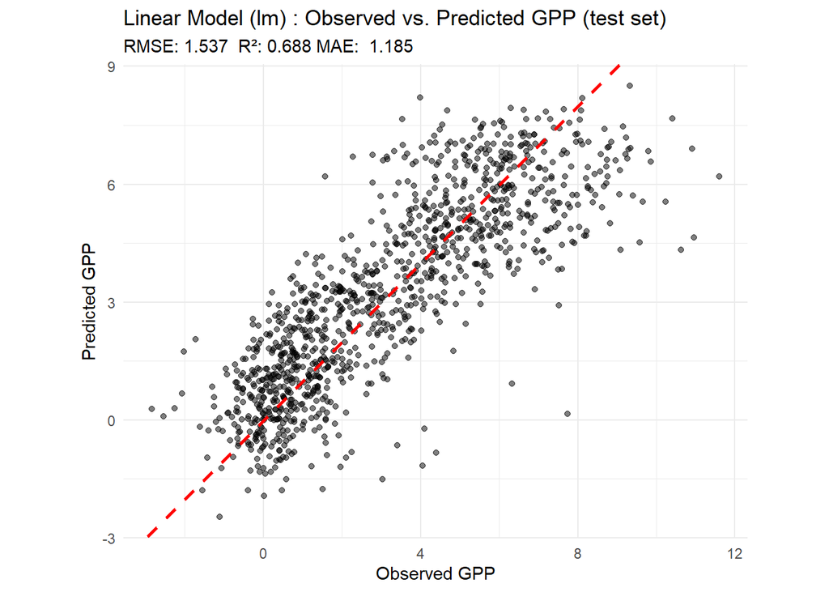

```r
# We define a function to calculate metrics and create plots
eval_model <- function(model, test_data, model_name) {

  # We make predictions on the test data
  predictions <- predict(model, newdata = test_data)

  # We create a data holding observed and predicted values
  eval_data <- data.frame(
    Observed = test_data$GPP,
    Predicted = predictions
  )

  # We calculate performance metrics using the built-in functions from the yardstick package
  rmse <- yardstick::rmse_vec(eval_data$Observed, eval_data$Predicted)
  rsquared <- yardstick::rsq_vec(eval_data$Observed, eval_data$Predicted)
  mae <- yardstick::mae_vec(eval_data$Observed, eval_data$Predicted)

  cat(paste0(model_name, " Performance on test set:\n"))
  cat(paste0("RMSE: ", round(rmse, 3), "\n"))
  cat(paste0("R-squared: ", round(rsquared, 3), "\n"))
  cat(paste0("MAE: ", round(mae, 3), "\n\n"))

  # Create scatter plot
  p <- ggplot(eval_data, aes(x = Observed, y = Predicted)) +
    geom_point(alpha = 0.5) +
    geom_abline(intercept = 0, slope = 1, linetype = "dashed", color = "red", linewidth=1) +
    labs(
      title = paste(model_name, ": Observed vs. Predicted GPP (test set)"),
      subtitle = paste("RMSE:", round(rmse, 3), " R²:", round(rsquared, 3), "MAE: ", round(mae, 3)),
      x = "Observed GPP",
      y = "Predicted GPP"
    ) +
    theme_minimal() +
    coord_fixed(ratio = 1) # This ensure axes have the same scale for 1:1 comparison

  print(p)
}

# We evaluate our lm_fit
lm_eval <- eval_model(model = lm_fit, test_data = test_data, model_name = "Linear Model (lm)")
```

## 5. K-Nearest Neighbors (KNN) model

```r
# We set the seed
set.seed(60249)

# We now train the knn model using the same recipe and train control from the linear model
knn_fit <- train(
  x = gpp_recipe,
  data = train_data,
  method = "knn",
  trControl = train_control,
  tuneGrid = data.frame(k = 8) # We use 8 nearest neighbors
)

# Print the results summary
print(knn_fit)
```

```
## k-Nearest Neighbors
##
## 2616 samples
##    7 predictor
##
## Recipe steps: YeoJohnson, center, scale
## Resampling: Cross-Validated (10 fold)
## Summary of sample sizes: 2353, 2354, 2355, 2354, 2355, 2355, ...
## Resampling results:
##
##   RMSE      Rsquared   MAE
##   1.436732  0.7286044  1.084466
##
## Tuning parameter 'k' was held constant at a value of 8
```

### 5.1 KNN model evaluation on test data

```r
# We use the same evaluation function we defined before
knn_eval <- eval_model(model = knn_fit, test_data = test_data, model_name = "KNN (k=8)")
```

```
## KNN (k=8) Performance on test set:
## RMSE: 1.438
## R-squared: 0.727
## MAE: 1.08
```

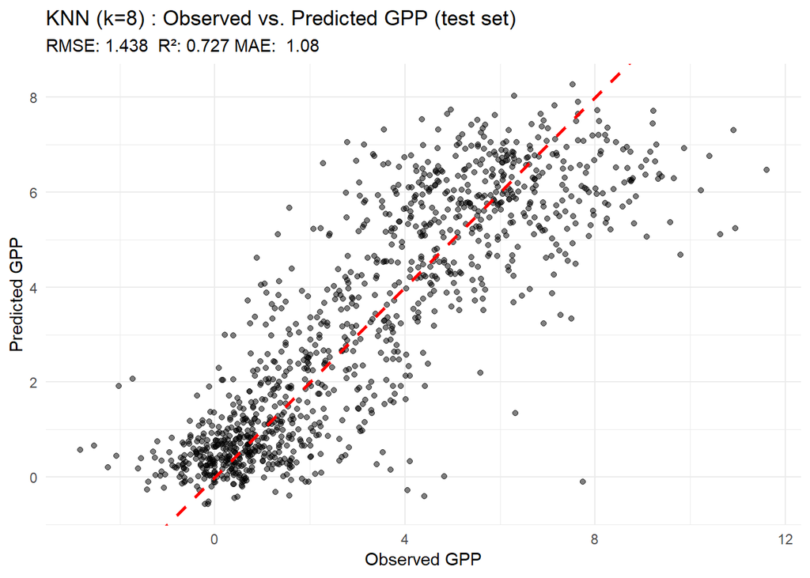

## 6. Results interpretation

Analyzing the evaluation between the training and the test set, we can observe some interesting results. The variance didn’t increase with the more complex KNN model compared to the simpler LM model. The R² drop was smaller for the KNN model and his value also higher:

```
  - LM: CV R² ≈ 0.698 --> Test R² ≈ 0.688 (Drop ≈ 0.010)

  - KNN (k=8): CV R² ≈ 0.729 --> Test R² ≈ 0.727 (Drop ≈ 0.002)
```

This means that the KNN model with k=8, despite being more flexible than the LM model,generalized well from the training data to the test data without significant overfitting.

The KNN model also had clearly better test set metrics (RMSE: 1.438 vs 1.537; R²: 0.727 vs 0.688). This means that it has a lower bias compared to the LM model. This also strongly suggests that the underlying relationship between the environmental predictors (temperature, radiation, VPD, etc.) and GPP is likely not strictly linear, so the the assumption of linearity of the LM model doesn’t fully capture the real-world complexity unlike the more flexible KNN model.

So in brief, the linear regression model is positioned more towards the high bias low variance end of the spectrum because of its rigid linear assumption preventing it from fitting the data perfectly. This inherent simplicity also means it’s less sensitive to noise in the training data, resulting in low variance, as evidenced by the small drop in performance from CV to test. The K-Nearest Neighbors model positioned more towards the lower bias end of the spectrum by being flexible enough to capture more of the true relationship. While more flexible models like KNN can be prone to higher variance, for this specific dataset and the choice of k=8 appears to have effectively managed this variance, leading to minimal overfitting, as shown by the very small drop in performance between CV and test results

## 7. Temporal variations of observed and modelled GPP

```r
# We create a new data frame for the plot
time_series_plot_data <- test_data

# We add predictions from the linear model
time_series_plot_data$lm_predictions <- predict(lm_fit, newdata = test_data)

# We add predictions from the KNN model
time_series_plot_data$knn_predictions <- predict(knn_fit, newdata = test_data)

# We select the GPP and the time column for plotting
plot_data_for_timeseries <- time_series_plot_data %>%
  select(
    Date = TIMESTAMP,
    Observed_GPP = GPP,
    LM_Predicted_GPP = lm_predictions,
    KNN_Predicted_GPP = knn_predictions
  ) %>%
  arrange(Date) # Ensure data is sorted by Date
```

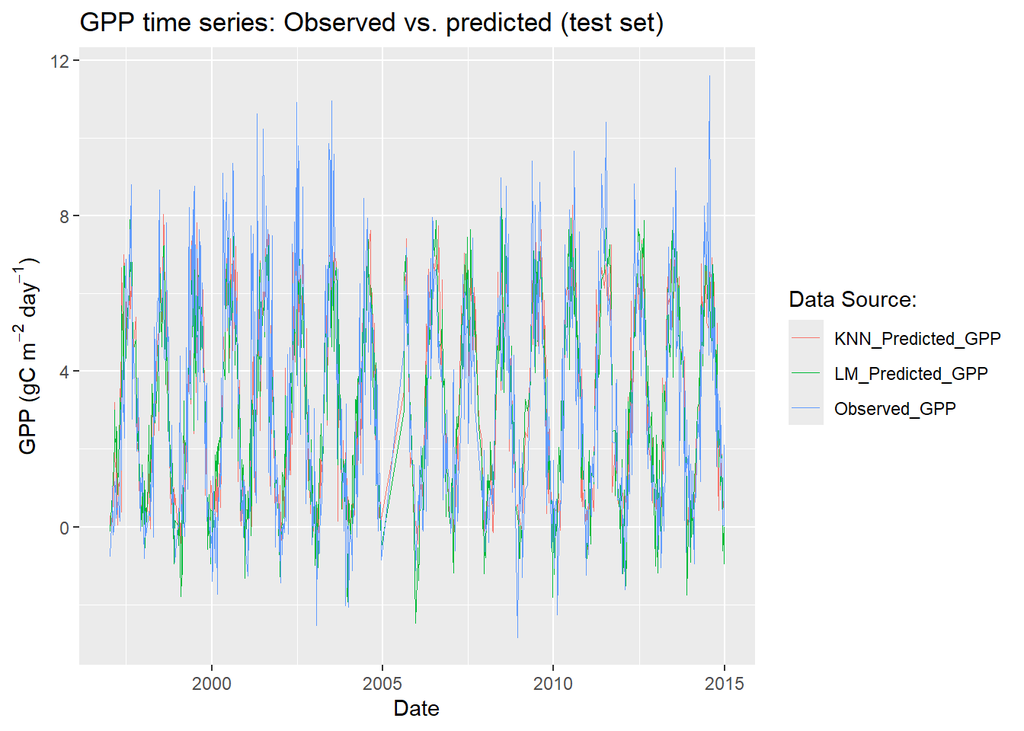

```r
# We reshape the data from wide to long format for ggplot2. Now we have a column for dates, a column "Source" which tells where each "GPP_Value" came from (observed, LM or KNN) and a "GPP_Value" column
plot_data_long <- plot_data_for_timeseries %>%
  pivot_longer(
    cols = c("Observed_GPP", "LM_Predicted_GPP", "KNN_Predicted_GPP"),                   # List the columns that we want to stack up
    names_to = "Source",
    values_to = "GPP_Value"
  )

# Create the time series plot
ggplot(plot_data_long, aes(x = Date, y = GPP_Value, color = Source)) +
  geom_line(alpha = 1, linewidth = 0) + # Adjusted alpha and linewidth
  labs(
    title = "GPP time series: Observed vs. predicted (test set)",
    x = "Date",
    y = expression("GPP (gC m"^-2*" day"^-1*")"), # Formatted y-axis label
    color = "Data Source:"
  )
```

# Part 2: KNN tuning

## 1. Hypothesis

As k approaches 1, the training set MAE should be very low, potentially close to 0 (the model basically “memorize” the training data points) but the test set MAE should be high, potentially close to 1 (the model overfitted pattern doesn’t generalize well on new data). The training set R² should be very high, potentially close to 1 (the model explains almost all the variance of the memorized training data), conversely the test set R² should be low (the model doesn’t generalize well, it explains little of the variance in the new data).

As k approaches N, the training set MAE should be high (because it basically predict the average GPP, so predictions are poor for single individual training points) and the test set MAE should also be high. The training set R² should be close to 0 (predicting the mean cannot explain the variance around it). The same is true for the test set R².

So, somewhere in the middle we should find an optimal k that minimize the variance and the bias (low MAE and high R²).

## 2. Testing the hypothesis

```r
# We define the range of k values we want to test
k_values <- c(1, 2, 3, 5, 8, 10, 15, 20, 25, 30, 40, 50, 100, 200, 300, 400)

# We initialize a data frame to store the results
performance_k <- data.frame()

# We set the seed
set.seed(60249)
```

```r
# Loop over each k value
for (k_val in k_values) {
  knn_model_k <- train(
    x = gpp_recipe,
    data = train_data,
    method = "knn",
    tuneGrid = data.frame(k = k_val),
    trControl = trainControl(method = "none") # We don't use resampling here because we want each specfic k on the full training set
  )

  # We make predictions on the training set
  train_preds_k <- predict(knn_model_k, newdata = train_data)

  # We calculate metrics for the training set
  train_mae_k <- mae_vec(truth = train_data$GPP, estimate = train_preds_k)
  train_rsq_k <- rsq_vec(truth = train_data$GPP, estimate = train_preds_k)

  # We make predictions on the testing set
  test_preds_k <- predict(knn_model_k, newdata = test_data)

  # We calculate metrics for the testing set
  test_mae_k <- mae_vec(truth = test_data$GPP, estimate = test_preds_k)
  test_rsq_k <- rsq_vec(truth = test_data$GPP, estimate = test_preds_k)

  # Store the results
  performance_k <- rbind(performance_k, data.frame(
    k = k_val,
    Train_MAE = train_mae_k,
    Train_R2 = train_rsq_k,
    Test_MAE = test_mae_k,
    Test_R2 = test_rsq_k
  ))
}

# Performance results
print(performance_k)
```

```
##      k Train_MAE  Train_R2 Test_MAE   Test_R2
## 1    1 0.0000000 1.0000000 1.413016 0.5866664
## 2    2 0.7214833 0.8763083 1.247038 0.6512680
## 3    3 0.8407085 0.8369914 1.191208 0.6781099
## 4    5 0.9176065 0.8055353 1.114832 0.7153459
## 5    8 0.9626886 0.7855885 1.079770 0.7272274
## 6   10 0.9735131 0.7810280 1.075674 0.7287119
## 7   15 0.9935056 0.7719515 1.073200 0.7296723
## 8   20 1.0142994 0.7659462 1.071238 0.7321936
## 9   25 1.0233242 0.7606773 1.068464 0.7336664
## 10  30 1.0344188 0.7569111 1.071480 0.7325704
## 11  40 1.0451819 0.7531379 1.070756 0.7322151
## 12  50 1.0529586 0.7497322 1.075865 0.7313780
## 13 100 1.0808292 0.7394119 1.086864 0.7276633
## 14 200 1.1233734 0.7281976 1.115812 0.7202601
## 15 300 1.1570463 0.7223568 1.144720 0.7154938
## 16 400 1.1900577 0.7175637 1.178498 0.7096853
```

```r
# We reshape the data in a long format
plot_data_train <- performance_k %>%
  select(k, Train_MAE, Train_R2) %>%
  pivot_longer(cols = c(Train_MAE, Train_R2), names_to = "Metric", values_to = "Value") %>%
  mutate(Metric = gsub("Train_", "", Metric)) # Clean up metric names

plot_data_test <- performance_k %>%
  select(k, Test_MAE, Test_R2) %>%
  pivot_longer(cols = c(Test_MAE, Test_R2), names_to = "Metric", values_to = "Value") %>%
  mutate(Metric = gsub("Test_", "", Metric)) # Clean up metric names
```

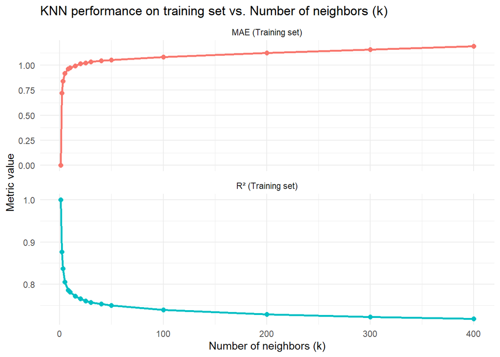

```r
ggplot_train_metrics <- ggplot(plot_data_train, aes(x = k, y = Value, group = Metric, color = Metric)) +
  geom_line(linewidth = 1) +
  geom_point(size = 2) +
  facet_wrap(~ Metric, scales = "free_y", ncol = 1, labeller = labeller(Metric = as_labeller(c(MAE = "MAE (Training set)", R2 = "R² (Training set)")))) +
  labs(
    title = "KNN performance on training set vs. Number of neighbors (k)",
    x = "Number of neighbors (k)",
    y = "Metric value",
    color = "Metric"
  ) +
  theme_minimal() +
  theme(legend.position = "none")

print(ggplot_train_metrics)
```

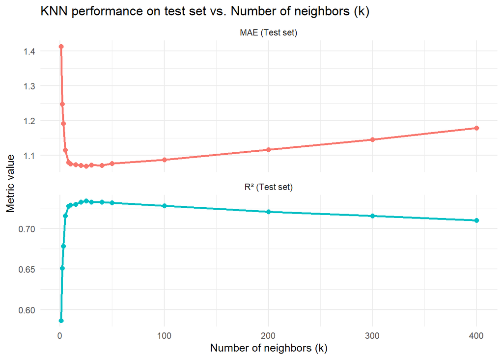

```r
ggplot_test_metrics <- ggplot(plot_data_test, aes(x = k, y = Value, group = Metric, color = Metric)) +
  geom_line(linewidth = 1) +
  geom_point(size = 2) +
  facet_wrap(~ Metric, scales = "free_y", ncol = 1, labeller = labeller(Metric = as_labeller(c(MAE = "MAE (Test set)", R2 = "R² (Test set)")))) +
  labs(
    title = "KNN performance on test set vs. Number of neighbors (k)",
    x = "Number of neighbors (k)",
    y = "Metric value",
    color = "Metric"
  ) +
  theme_minimal() +
  theme(legend.position = "none")

print(ggplot_test_metrics)
```

We can observe the overfitting region from the large discrepancy of performance between the training set and the test set. When the k value is low (e.g., k=1), we have excellent performance (extremely low MAE and extremely high R²) for the training set but very poor performance for the test set (low R² and high MAE). This indicates the model has learned the noise in the training data and doesn’t generalize.

### 2.1. K-MAE function

```r
# We define the function
calculate_test_mae_for_k <- function(k_value,
                                     recipe_obj,
                                     training_data,
                                     testing_data,
                                     target_variable_name = "GPP") {knn_model <- train(x = recipe_obj, data = training_data, method = "knn", tuneGrid = data.frame(k = k_value), trControl = trainControl(method = "none"))

  # We make predictions on the testing set
  test_predictions <- predict(knn_model, newdata = testing_data)

  # We calculate MAE for the testing set
  test_mae <- mae_vec(truth = testing_data[[target_variable_name]], estimate = test_predictions)

  # Return the calculated MAE
  return(test_mae)
}
```

```r
# Examples of use
#k=5
mae_for_k5 <- calculate_test_mae_for_k(k_value = 5,
                                       recipe_obj = gpp_recipe,
                                       training_data = train_data,
                                       testing_data = test_data,
                                       target_variable_name = "GPP") #
print(paste("MAE for k=5:", mae_for_k5))
```

```
## [1] "MAE for k=5: 1.11483162059038"
```

```r
# k=10
mae_for_k10 <- calculate_test_mae_for_k(k_value = 10,
                                        recipe_obj = gpp_recipe,
                                        training_data = train_data,
                                        testing_data = test_data)
print(paste("MAE for k=10:", mae_for_k10))
```

```
## [1] "MAE for k=10: 1.07567435156359"
```

```r
# k=20
mae_for_k20 <- calculate_test_mae_for_k(k_value = 20,
                                        recipe_obj = gpp_recipe,
                                        training_data = train_data,
                                        testing_data = test_data)
print(paste("MAE for k=20:", mae_for_k20))
```

```
## [1] "MAE for k=20: 1.07123773751289"
```

## 3. K tuning

```r
# Define a grid of k values to search
k_values <- data.frame(k = 1:30)

# Set seed
set.seed(60249)

# We train the KNN model over the k_values
knn_tuned_model_for_optimal_k <- train(
  x = gpp_recipe,
  data = train_data,
  method = "knn",
  trControl = train_control,
  tuneGrid = k_values,
  metric = "MAE"             # We optimize for MAE
)

# Print the results summary
print(knn_tuned_model_for_optimal_k)
```

```
## k-Nearest Neighbors
##
## 2616 samples
##    7 predictor
##
## Recipe steps: YeoJohnson, center, scale
## Resampling: Cross-Validated (10 fold)
## Summary of sample sizes: 2353, 2354, 2355, 2354, 2355, 2355, ...
## Resampling results across tuning parameters:
##
##   k   RMSE      Rsquared   MAE
##    1  1.933385  0.5661631  1.440772
##    2  1.660632  0.6516249  1.254083
##    3  1.562504  0.6835610  1.186117
##    4  1.508530  0.7026052  1.144814
```

[output cut: 29 more lines]

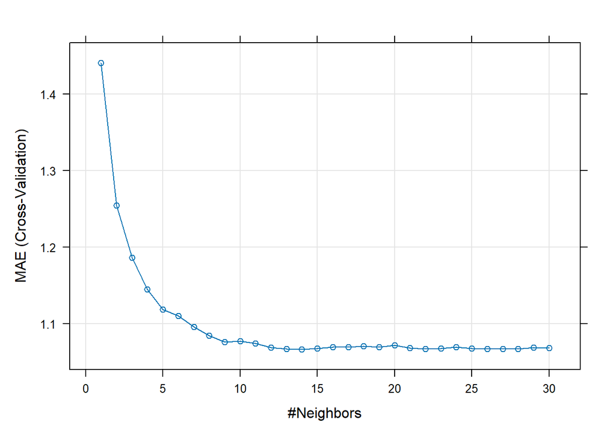

```r
# Plot the tuning results
plot(knn_tuned_model_for_optimal_k)
```

```r
# Get the best k value found
print(knn_tuned_model_for_optimal_k$bestTune)
```

```
##     k
## 14 14
```

```r
optimal_knn_eval <- eval_model(model = knn_tuned_model_for_optimal_k,
                               test_data = test_data,
                               model_name = "Optimal KNN (k=14)")
```

```
## Optimal KNN (k=14) Performance on test set:
## RMSE: 1.428
## R-squared: 0.729
## MAE: 1.074
```

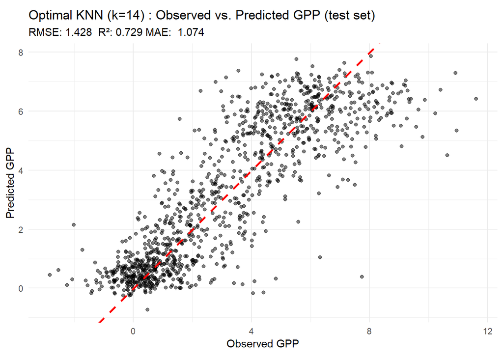